# TP Bachelor RSS (Reliability Serial System)

S. Jaubert

05 février 2021

Supposons qu’un technicien s’intéresse au calcul de la fiabilité d’un système en série composé de trois composants avec les délais souhaités avant défaillance suivants : 12 semaines pour la machine 1, 15 semaines pour la machine 2 et 15 semaines pour la machine 3.

Le technicien a pu recueillir 100 temps de défaillance pour les machines 1 et 2 et 81 temps de défaillance pour la machine 3. (Source : https://github.com/sjaubert/Python-for-Industrial-Engineering/blob/master/Total%20Productive%20Maintenance/failure_times.csv)

Entrons les données :

```r
setwd("D:/OneDrive - CFAI Centre/Bachelor/Fiabilité")
failure_time<-read.csv(file ="failure_times.csv")
```

Comparaison graphique des distributions :

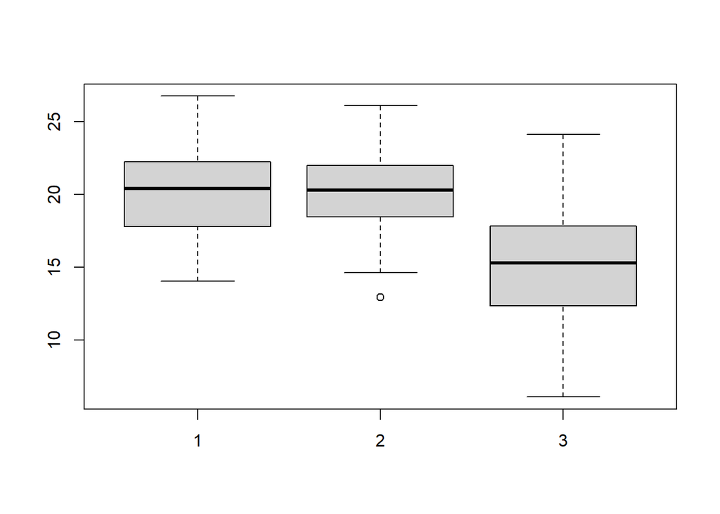

```r
boxplot(failure_time$machine.1,failure_time$machine.2,failure_time$machine.3)
```

Résumé statistique :

```r
summary(failure_time)
```

```
##    machine.1       machine.2       machine.3
##  Min.   :14.02   Min.   :12.93   Min.   : 6.076
##  1st Qu.:17.77   1st Qu.:18.48   1st Qu.:12.346
##  Median :20.40   Median :20.28   Median :15.289
##  Mean   :20.27   Mean   :20.19   Mean   :15.133
##  3rd Qu.:22.25   3rd Qu.:21.96   3rd Qu.:17.809
##  Max.   :26.76   Max.   :26.13   Max.   :24.106
##                                  NA's   :19
```

### Machine 1

Utilisation de la méthode des rangs médians

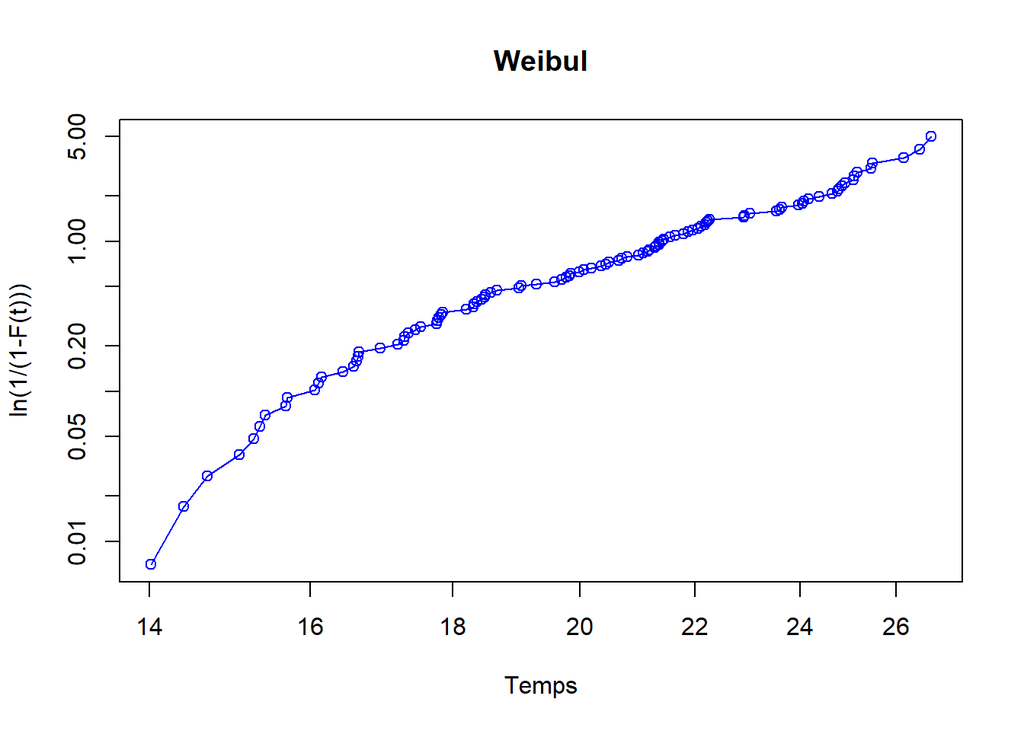

```r
p1<-ppoints(sort(failure_time$machine.1),a=0.3)
plot(x = sort(failure_time$machine.1),y = -log(1-p1),log = "xy",type = "o",col="blue",xlab = "Temps",ylab = "ln(1/(1-F(t)))",main = "Weibul")
```

De façon plus précise avec la librairie WeibullR :

```r
library(WeibullR)
res1<-MRRw2p(failure_time$machine.1,bounds = T,show = T)
```

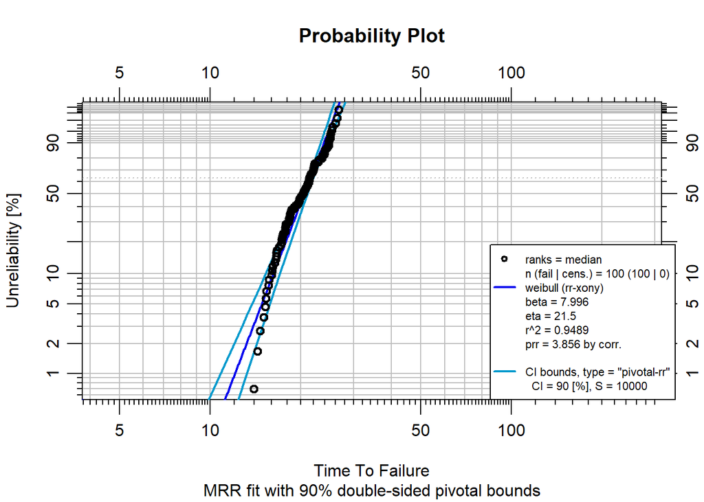

Nous sortons de l’intervalle de confiance au début et à la fin. Essayons avec 3 paramètres :

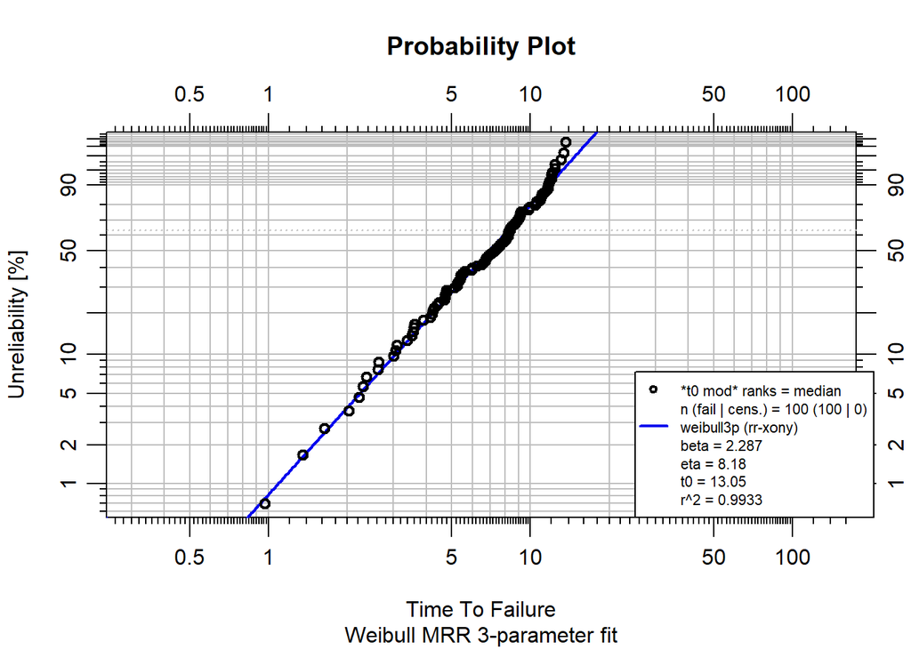

```r
MRRw3p(x = failure_time$machine.1,show = T)->res1_3p
```

Cela semble un peu meilleur.

Pour mieux apprécier le meilleur modèle, représentons les sur le même graphique :

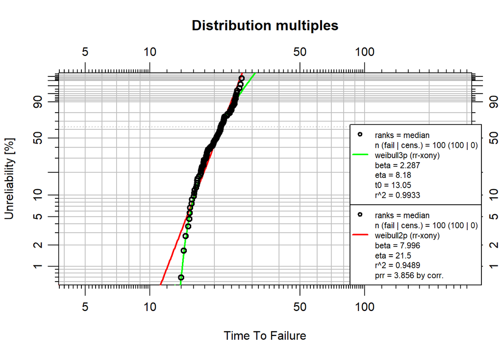

```r
obj1<-wblr(failure_time$machine.1)#Création d'un objet de classe "wblr" pour un traitement ultérieur


# le paramètre dist spécifie la distribution cible pour l'ajustement. Les valeurs possibles sont "weibull", "weibull2p", "weibull3p" (trois paramètres Weibull), "lognormal "ou "lognormal3p". La valeur par défaut est "weibull".

obj1<-wblr.fit(obj1,col="red",dist="weibull2p")
#Cette fonction adapte les distributions de probabilité aux objets wblr.
obj1<-wblr.fit(obj1,col="green",dist="weibull3p",lwp=3)
plot(obj1,main="Distribution multiples")
```

Il ne fait aucun doute que le modèle de Weibull à 3 paramètres est le meilleur.

```r
res1_3p
```

```
##        Eta       Beta         t0       Rsqr
##  8.1803667  2.2866977 13.0482965  0.9933458
```

La fonction de fiabilité de la machine 1 s’écrit donc :

$$R_{1}(t)=e^{-(\frac{t-13.05}{8.18})^{2.287}}$$

Nous voyons ainsi qu’en translatant nos donnée initiales de gamma :

```r
failure_time$machine.1-13.05->ntime
```

Puis en refaisant un calcul selon les rangs médians, cette fois nous trouvons bien une droite :

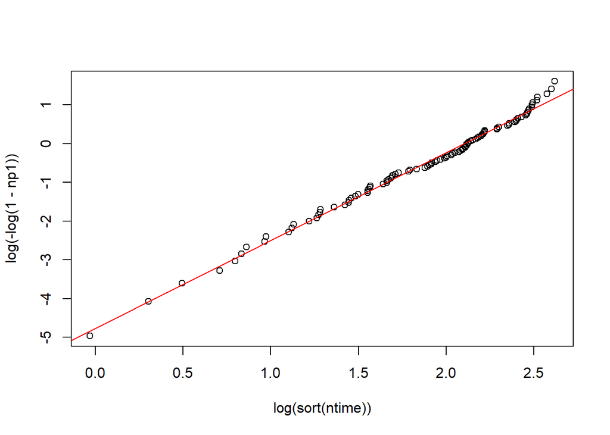

```r
np1<-ppoints(sort(ntime),a=0.3)

lm(formula = log(-log(1-np1))~log(sort(ntime)))->ml1
plot(log(sort(ntime)),log(-log(1-np1)));abline(ml1,col="red")
```

```r
ml1$coefficients
```

```
##      (Intercept) log(sort(ntime))
##        -4.767796         2.266755
```

La pente correspond sensiblement à ce qu’on avait trouvé ($\beta=2.287$) et $\eta$ se retrouve par :

```r
beta<-ml1$coefficients[2]
(eta<-exp(-ml1$coefficients[1]/beta))
```

```
## (Intercept)
##    8.193631
```

Enfin nous pouvons superposer la courbe de la densité théorique avec les données expérimentales :

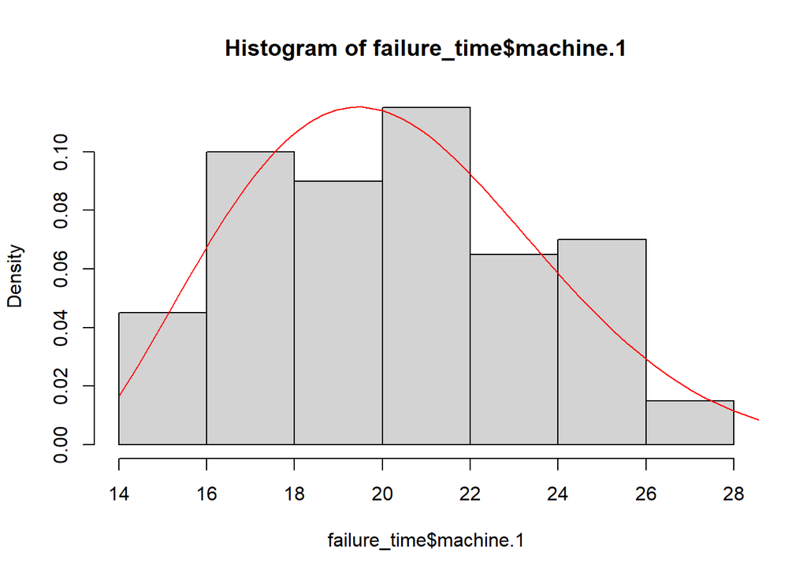

```r
hist(failure_time$machine.1,probability = T);curve(expr = dweibull(x-13.08,shape = 2.287,scale = 8.18),from = 14,to = 29,add = T,col="red")
```

**1°) En vous inspirant de ce qui a été fait, retrouver les densités de Weibull pour les machines 2 et 3**

**2°) Les machines 1, 2 et 3 étant d’un point de vue de la fiabilité disposées en série, quelle est la fiabilité du système à la 12ème et 15ème semaine ?**

### **Correction**

Fonction de fiabilité de la machine 2

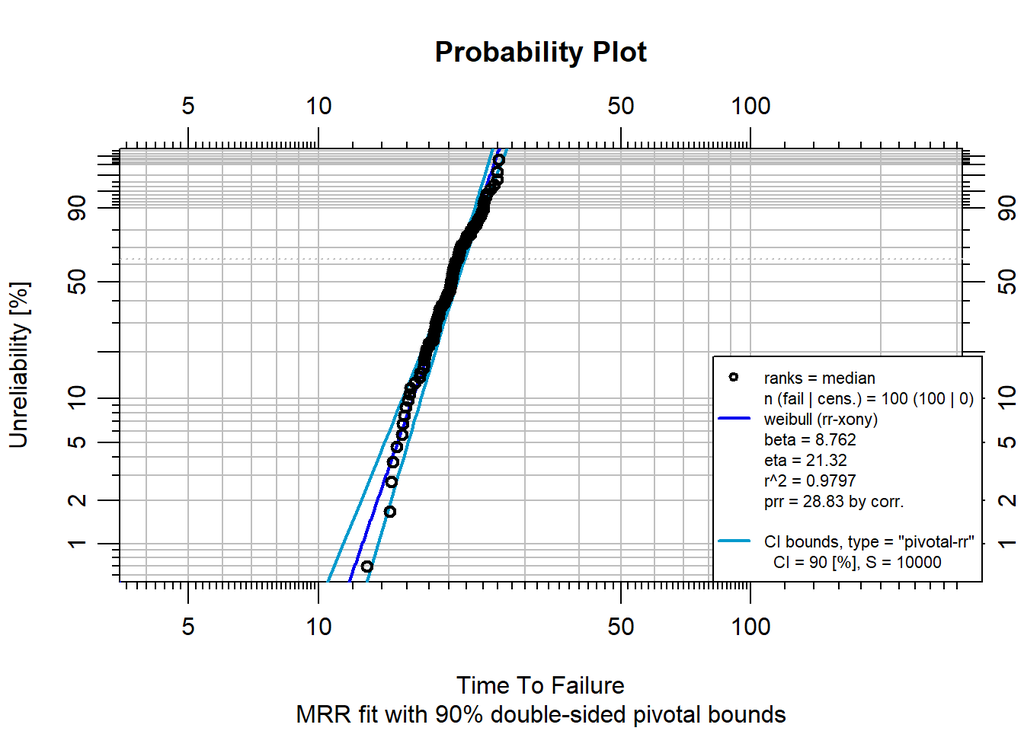

```r
MRRw2p(x = failure_time$machine.2,bounds = T,show = T)->res2
```

Regardons avec 3 paramètres :

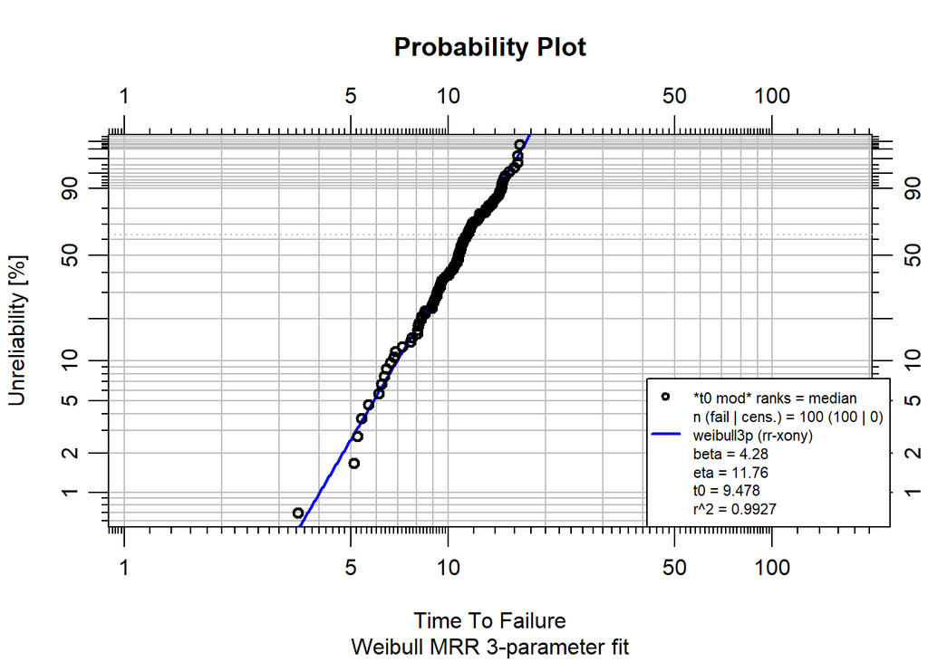

```r
MRRw3p(x = failure_time$machine.2,show = T)->res2_3p
```

Nous utiliserons ce modèle pour la machine 2

Pour la 3ème machine :

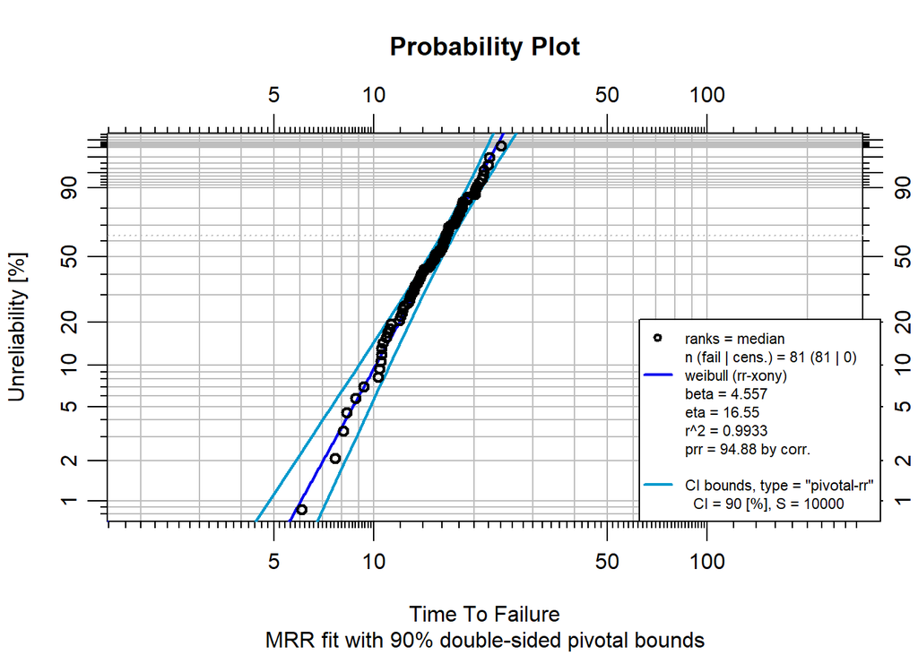

```r
MRRw2p(failure_time$machine.3[1:81],bounds = T,show = T)->res3
```

Avec un R²=0.9933, inutile d’aller chercher ici un modèle à 3 paramètres.

2°)

```r
Rw<-function(t,beta,gamma,eta){
  r<-exp(-((t-gamma)/eta)^beta)
  return(r)
}
```

Fiabilité à la 15ème semaine, d’un point de vue de la fiabilité les machines sont disposées en série, nous faisons donc le produit :

```r
Rw(t = 15,beta = res1_3p[2],gamma = res1_3p[3],eta = res1_3p[1])*Rw(t = 15,beta = res2_3p[2],gamma = res2_3p[3],eta = res2_3p[1])*Rw(t = 15,beta = res3[[1]][2],gamma = 0,eta = res3[[1]][1])
```

```
##        t0
## 0.4890586
```

La fiabilité à la 15ème semaine n’est plus que de 48,9%

Pour la douzième semaine, il faut prendre garde que si nous appliquons le modèle de la machine 1 à 3 paramètres, nous aurons une erreur car $12<\gamma=13.048$

```r
Rw(t = 12,beta = res1[[1]][2],gamma = 0,eta = res1[[1]][1])*Rw(t = 12,beta = res2_3p[2],gamma = res2_3p[3],eta = res2_3p[1])*Rw(t = 12,beta = res3[[1]][2],gamma = 0,eta = res3[[1]][1])
```

```
##       Eta
## 0.7852974
```

On peut constater qu’en l’espace de 3 semaines la fiabilité a chuté de près de 30% !